# REPORTE DE CONTRATOS DIRECTOS

Durante el preriodo de emergencia

Abner Francisco Casallo Trauco

2020-11-27

# Organismo Supervisor de las Contrataciones del Estado (OSCE)

EL OSCE es el supervisor de los procesos de contratación pública que realizan las entidades del Estado. Actualmente cuenta con el Sistema Electrónico de Contrataciones del Estado (SEACE), que es el sistema electrónico que permite el intercambio de información y difusión sobre las contrataciones del Estado, buscando la transparencia de los procesos.

[figure not shown]

[figure not shown]

# INTRODUCCIÓN

Este es un breve reporte del análisis exploratorio de los procesos de contratación directa durante el estado de emergencia.

## ANÁLISIS DEPARTAMENTAL

### DE ACUERDO AL NÚMERO DE CONTRATOS

Departamentos de acuerdo al número de contratos.

| ENTIDAD_DEPARTAMENTO | MONTOADJUDICADOSOLES | num_contr |
| --- | --- | --- |
| LIMA | 1255.28118 | 2344 |
| ANCASH | 52.11226 | 243 |
| LA LIBERTAD | 25.70506 | 225 |
| CAJAMARCA | 25.64520 | 224 |
| SAN MARTIN | 77.47497 | 224 |

Lima es el que tiene más contratos, seguido de Ancash, La Libertad, Cajamarca y San Martín.

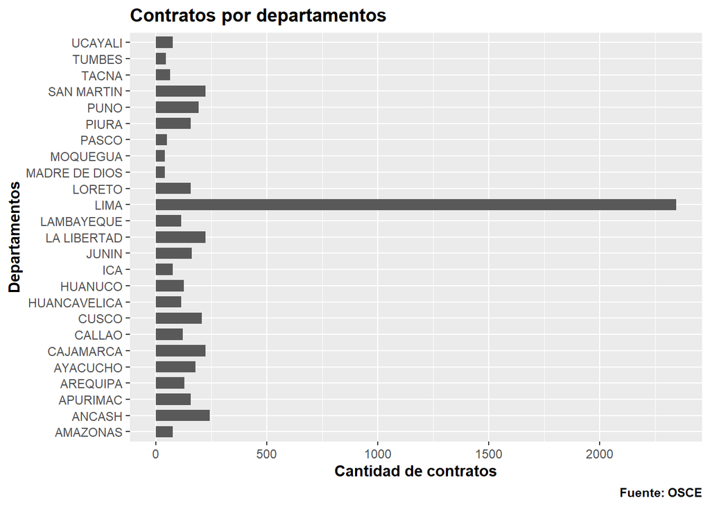

### DE ACUERDO AL MONTO

Departamentos de acuerdo al monto contratado

| ENTIDAD_DEPARTAMENTO | MONTOADJUDICADOSOLES | num_contr |
| --- | --- | --- |
| LIMA | 1255.28118 | 2344 |
| SAN MARTIN | 77.47497 | 224 |
| CUSCO | 55.61189 | 207 |
| ANCASH | 52.11226 | 243 |
| TACNA | 34.12541 | 65 |

Lima es el que tiene un mayor monto en contrataciones, seguido de San Martín, Cuzco y Ancash.

## ANÁLISIS POR PROVEEDORES (EN GENERAL)

### DE ACUERDO AL NÚMERO DE CONTRATOS

Proveedores e acuerdo al número de contratos.

| PROVEEDOR | RUCPROV | MONTOADJSOLES | Contratos |
| --- | --- | --- | --- |
| NA | 20555589574 | 10.009620 | 42 |
| UTILITARIOS MEDICOS S.A.C. | 20419385442 | 7.680130 | 31 |
| PRAXAIR PERU SRL | 20338570041 | 8.296686 | 29 |
| R & G SEGURIDAD E HIGIENE INDUSTRIAL S.A.C. | 20523717759 | 23.359655 | 27 |
| TEXTILES CAMONES S.A. | 20293847038 | 12.010010 | 27 |

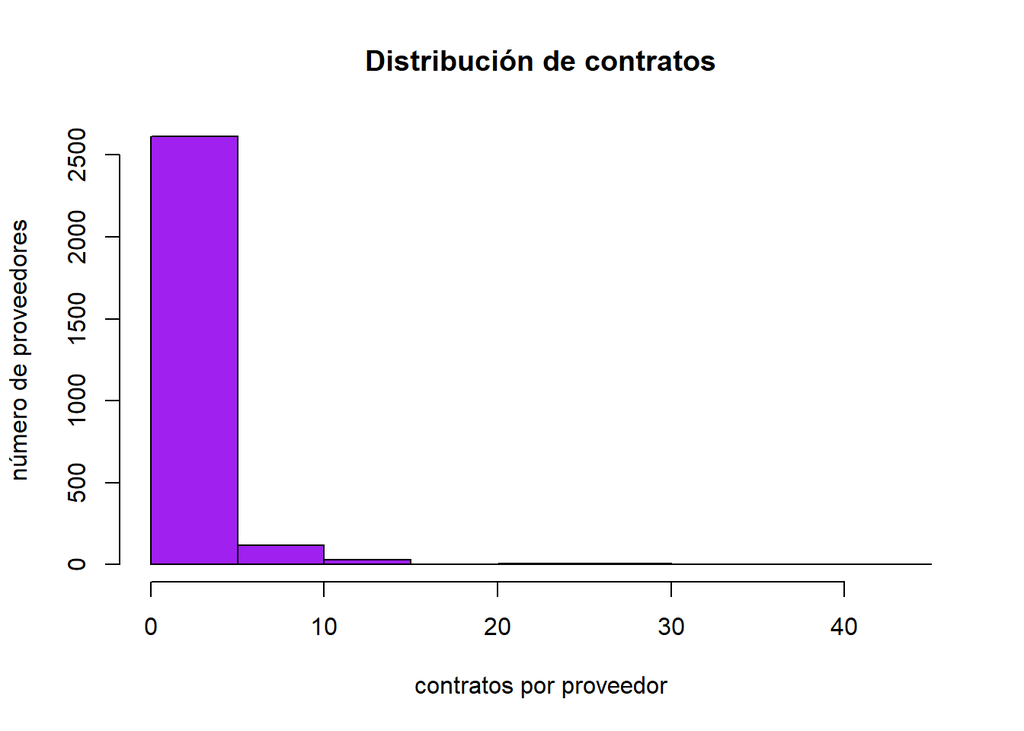

### DE ACUERDO AL MONTO

Proveedores de acuerdo al monto.

| PROVEEDOR | RUCPROV | MONTOADJSOLES | Contratos |
| --- | --- | --- | --- |
| R & G SEGURIDAD E HIGIENE INDUSTRIAL S.A.C. | 20523717759 | 23.359655 | 27 |
| TEXTILES CAMONES S.A. | 20293847038 | 12.010010 | 27 |
| NA | 20555589574 | 10.009620 | 42 |
| PRAXAIR PERU SRL | 20338570041 | 8.296686 | 29 |
| UTILITARIOS MEDICOS S.A.C. | 20419385442 | 7.680130 | 31 |

¿QUIÉN ES EL NA? VER RUC E INFORMACIÓN EN LA RED. Según SUNAT es “L & M MEDICAL SUPPLIES” (SOCIEDAD ANONIMA CERRADA)

## ANÁLISIS DE PROVEEDORES QUE SON PERSONAS NATURALES

### De acuerdo al número de contratos

Proveedores personas naturales de acuerdo al número de contratos.

| PROVEEDOR | RUCPROV | MONTOADJSOLES | Contratos |
| --- | --- | --- | --- |
| RUIZ PEZO JULIO CESAR | 10458708202 | 0.2390140 | 12 |
| VALERO LADERA LUISA JULIA | 10423032842 | 0.5992230 | 11 |
| CHUCHON PINEDA MARILYN KELLY | 10425565864 | 4.0172200 | 8 |
| TACHIBANA ATANACIO CESAR HERCULANO | 10422665931 | 0.2583200 | 8 |
| PALACIOS NAVARRO AMERICA | 10026473255 | 0.8747875 | 7 |

## ¿QUÉ OBJETO SE CONTRATÓ MÁS?

Objetos contratados

| OBJETOCONTRACTUAL | MONTOADJSOLES | Contratos |
| --- | --- | --- |
| Bien | 1254.563259 | 4335 |
| Servicio | 502.043940 | 1158 |
| Obra | 57.612220 | 49 |
| Consultoría de Obra | 1.187068 | 14 |

## ENTIDAD

### EN GENERAL DE ACUERDO AL NÚMERO DE CONTRATOS

Entidades y Proveedores de acuerdo al número de contratos.

| ENTIDAD | PROVEEDOR | RUCPROV | MONTOADJSOLES | Contratos |
| --- | --- | --- | --- | --- |
| CENTRO NACIONAL DE ABASTECIMIENTO DE RECURSOS ESTRATEGICOS EN SALUD | TEXTILES CAMONES S.A. | 20293847038 | 12.010010 | 27 |
| SEGURO SOCIAL DE SALUD | DISTRIBUIDORA DROGUERIA SAGITARIO S.R.L. | 20171586608 | 40.257452 | 21 |
| CENTRO NACIONAL DE ABASTECIMIENTO DE RECURSOS ESTRATEGICOS EN SALUD | NA | 20555589574 | 5.691364 | 19 |
| MINISTERIO DE COMERCIO EXTERIOR Y TURISMO | CORPORACION EL GOLF S.A. | 20136957253 | 3.868900 | 15 |
| MUNICIPALIDAD PROVINCIAL DE MARISCAL RAMON CASTILLA | INVERSIONES ALI & DANI EMPRESA INDIVIDUAL DE RESPONSABILIDAD LIMITADA | 20541200101 | 0.456000 | 13 |

### CASO DE PERSONAS NATURALES

Entidades y proveedores personas naturales de acuerdo al número de contratos.

| ENTIDAD | PROVEEDOR | RUCPROV | MONTOADJSOLES | Contratos |
| --- | --- | --- | --- | --- |
| MUNICIPALIDAD PROVINCIAL DE MARISCAL RAMON CASTILLA | RUIZ PEZO JULIO CESAR | 10458708202 | 0.2390140 | 12 |
| EJERCITO PERUANO | CHUCHON PINEDA MARILYN KELLY | 10425565864 | 4.0172200 | 8 |
| PROGRAMA NACIONAL DE SANEAMIENTO URBANO | TACHIBANA ATANACIO CESAR HERCULANO | 10422665931 | 0.2583200 | 8 |
| EJERCITO PERUANO | TORIBIO QUINTO ADRIANA LUZ | 10432690259 | 0.6691686 | 6 |
| GOBIERNO REGIONAL DE SAN MARTIN-SALUD | PRADO CABANILLAS DONILA | 10164556986 | 0.2926000 | 6 |